# InPreD_README

### 7.4 Prepare small variant table (Legacy method)

- Open excel and open the small variant table (.tsv file)) e.g.:*IPA0123_D01-d01-A01_small_variant_table.tsv”* situated in in `${DURABLE}/TSO500_postprocessing/_TSO500_TSOPPI_v0.3.2_main_2022_06_07/IPA0123`
- In the text import wizard from excel select *Delimited* and click on *Next*.

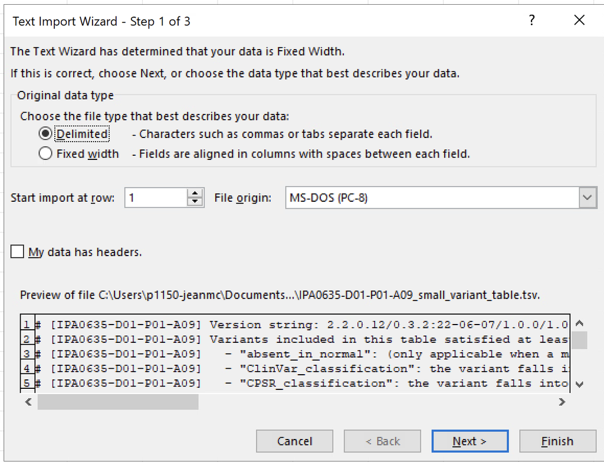

**Figure 28.** Select Delimited in the text import wizard from excel

- Then select *Tab* as delimiter and click on *Next*

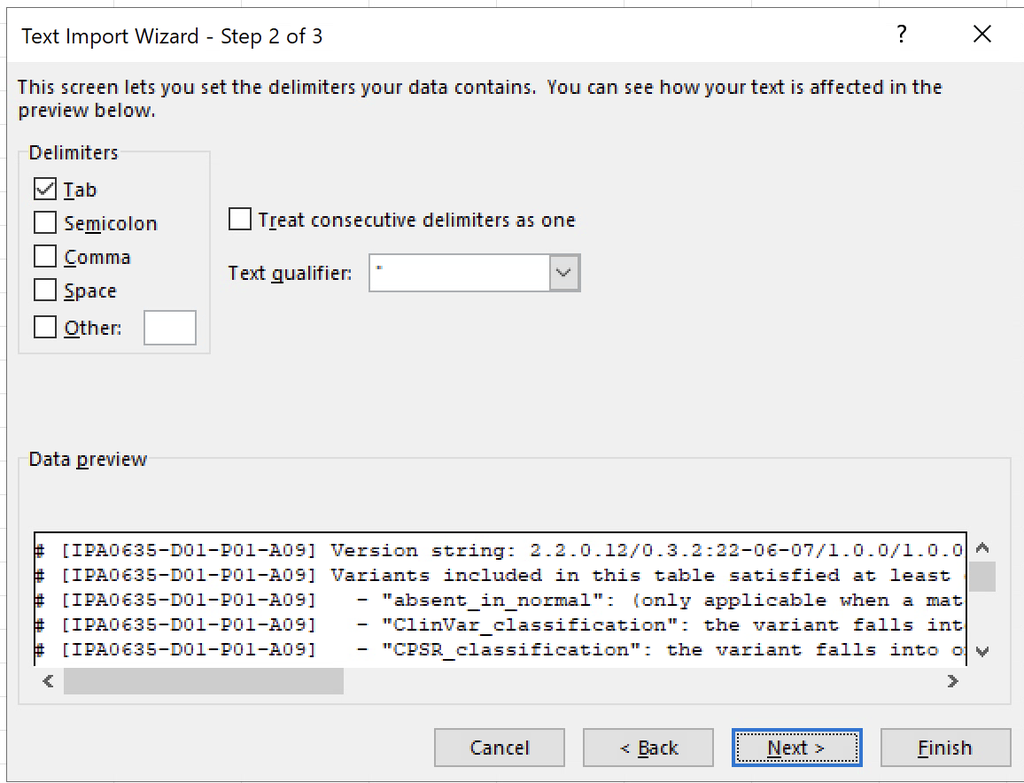

**Figure 29.** Select Tab as delimiter in the text import wizard from excel

- Then select *Text* as column data format and click on *Finish*.

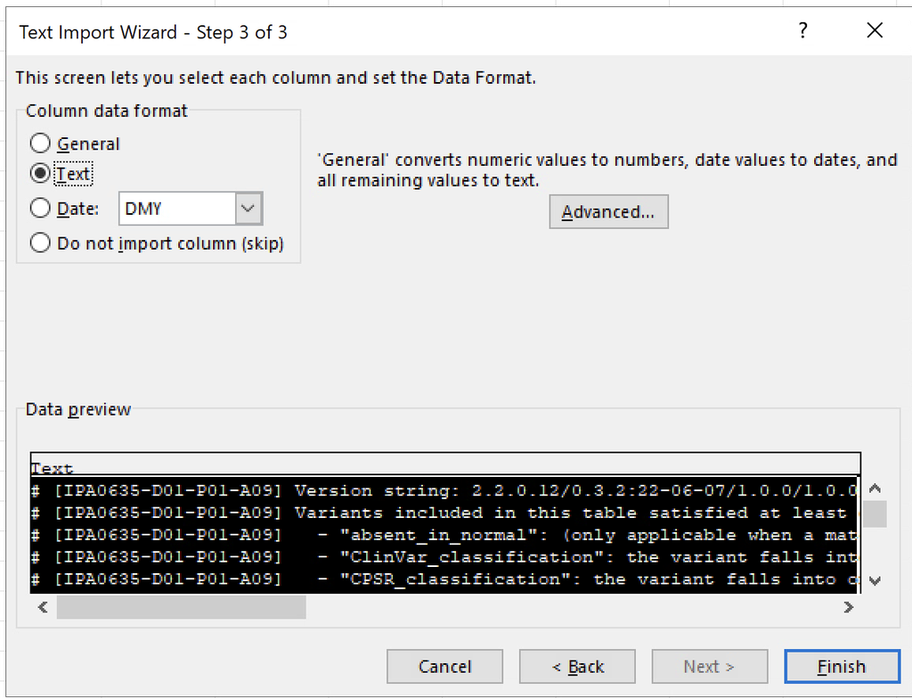

**Figure 30.** Select Text as column data format in the text import wizard from excel

- Save the file as excel workbook *.xlsx* format and add **_forQC** to the filename.

**NOTE:** this is important to add exatly **_forQC** at the end as the rest of the pipeline depends on it.

- Now only keep columns *“Gene_symbol”, “Genomic_location”, “DNA_change”, “Protein_change”, “Coding_status”, “Tier”, “AF_tumor_DNA”, “Depth_tumor_DNA”, “Depth_tumor_RNA”, “TSO500_recurrence”, “TSO500_LocalApp_class”, “Class_judgement”, “Class_judgement_comments”, “Mutation_hotspot”, “CPSR_ACMG_class”, “CPSR_ClinVar_class”, “Run_QC”* and hide the others (**Do not delete any column**)
- The table is now ready for QC.

### 7.5 Check concordance between DNA and RNA (Legacy method)

- Find the file *sample_concordance.tsv* in the same folder as previously (e.g.: *IPA0123_D01-d01-A01_sample_concordance.tsv”* located in in `${DURABLE}/TSO500_postprocessing/_TSO500_TSOPPI_v0.3.2_main_2022_06_07/IPA0123/`
- Open the file with a text editor and check the column **Hom_concordance**. Concordance beterrn DNA and RNA should be **above 80%**.

### 7.6 Assess concordance of patient gender between pronto metadata and overview plot (Legacy method)

- Open the overview plot PDF for the sample being QC, e.g.: *IPA0123_D01-d01-A01_CNV_overview_plots.pdf”* located in in `${DURABLE}/TSO500_postprocessing/_TSO500_TSOPPI_v0.3.2_main_2022_06_07/IPA0123/`
- Open the PRONTO_metadata file for this run: `${DURABLE}/TSO500_pronto_metadata/PRONTO_metadata_NA.txt` in the column *Sex*.
- Compare the gender for the same sample in both files and verify they are concordant.

### 7.7 Check concordance in tumor content between pureCN and cytology results (Legacy method)

- The tumor content estimated by cytology can be found in the pronto metadata file for this run: `${DURABLE}/TSO500_pronto_metadata/PRONTO_metadata_NA.txt` in the column *Tumor_content_pathology*.
- The tumor content estimated by cytology can also be found in the overview plot PDF for the sample being QC, e.g.: *IPA0123_D01-d01-A01_CNV_overview_plots.pdf”* located in in `${DURABLE}/TSO500_postprocessing/_TSO500_TSOPPI_v0.3.2_main_2022_06_07/IPA0123/` in the title of plot [A2] *assumed tumor cell fraction*
- The tumor content estimated by pureCN for the sample being QC, e.g.: *IPA0123_D01-d01-A01*, can be found in `${DURABLE}/TSO500_icnva/_TSO500_TSOPPI_v0.3.2_main_2022_06_07/IPA0123_D01-d01-A01_icnva/PureCN_results_default/IPA0123_D01-d01-A01_solution_overview.tsv` in the column *purity*.
- Compare the tumor content estimated by cytology with the pureCN solution 1, there is no specific threshold for difference but large differences (eg: more than 20%) should be reported.

### 7.8 Do the QC

- Both Class_judgement and Class_judgement_comments columns are pre-filled by TSOPPI based on rules listed in the small variant table header. The pre-filling is intended to speed up the manual QC process by automating multiple well-defined quality checks, but variant reviewers should always check whether they agree with the auto-generated judgement information and conclusions.
- For both variants that have a Class_judgement **include** and **exclude** there is no need to QC synonymous and non coding variants, this information can be found in the column *Coding_status*.
- Start the QC by first looking at **exclude** variants in the column Class_judgement.

[figure not shown]

**Figure 28.** Location of the class judgement and class judgement comments columns in the small variant table

- To verify the **exclude** variants, look at the *Class_judgement_comments*, column to understand the reason for the exclusion (e.g.: Germline variant, blacklisted, etc…)
- For the **exclude** variants, while it is important to verify all, pay a particular attention to the **somatic** ones and why they have been excluded. Sometime a variant has beed excluded due to allele frequency but the tumor content is low and therefore the adjusted allele frequency would be higher than reported.
- If a **exclude** variant is not correctly excluded, change the *Class_judgement* to **include** and write in the *Class_judgement_comments* column the reason for the inclusion. This variant will also need to be checked by IGV in the next step.
- Once all the **exclude** variants have been verified move to the **include** variants

**NOTE:** Check VAF for black listed variants if VAF is high (above 30%) they might be included.

- For those copy the genomic location (column *Genomic_location*) and paste it in IGV in the search bar on the top and press enter to go to the location of the variant.

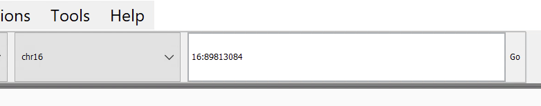

**Figure 29.** Location of the IGV search bar for verifying variants in the BAM files

- Once at the correct location, right click and select *View as pairs* then right click again and select *Sort alignments by* → *base* to sort the reads by the base at the position of the variant.

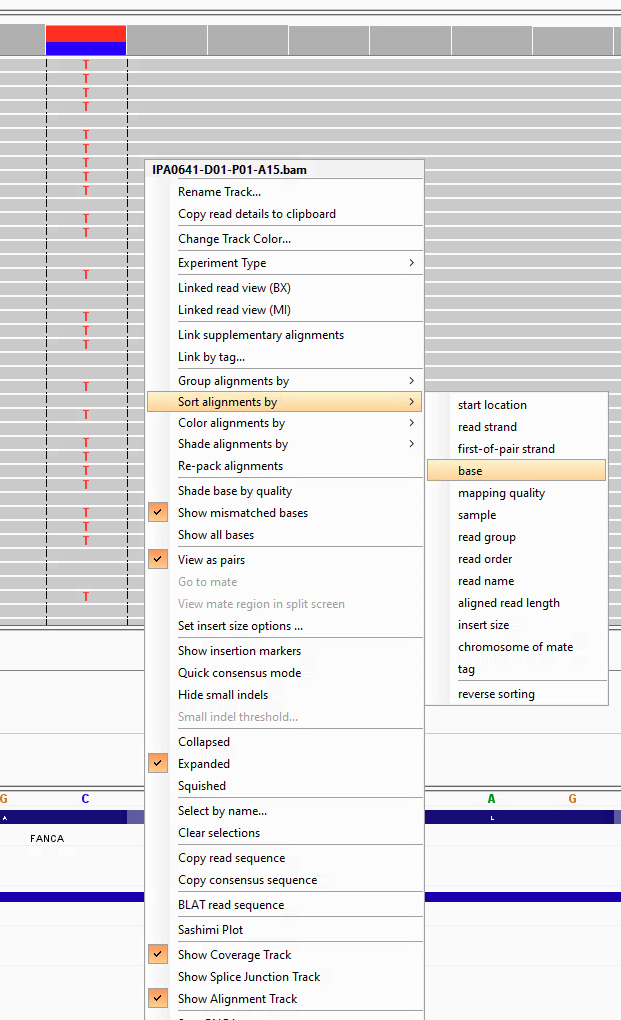

**Figure 30.** Sort the reads by base in IGV

- Now check if the correct variant can be found, if the alignment is correct and if multiple reads support the variant.

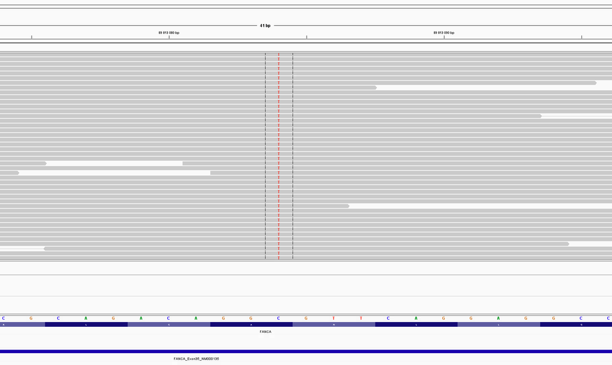

**Figure 31.** Verify the presence of the variant in IGV

**NOTE:** When leaving a comment in the *Class_judgement_comments* column, do not leave empty space as those are not suported by Pronto, replace each space by an underscore.

## 8 Email Drafts

### 8.1 When *TSOPPI* and *ICNVA* are ready

```
Dear all,

TSOPPI and ICNVA analysis are running now.
The small variant tables should be ready for QC in ~30 minutes.

Please, let us know when QC is ready to proceed with the reports.

Best,

Jaime & Jean-Marc
```

### 8.2 When reports are ready in TSD

```
Title: Bioinformatic analysis week WW

Dear all,

The reports and all the related data are now available in the InPred folder. We have sequenced and processed N IPA cases (IPA0, IPA0, IPA0, IPA0, IPA0, IPA0, IPA0, IPA0 ).

Sequencing went fine.

Torben, Shixiong, Andliena: there are some fusions reported, which ones should I plot?

We observed some sequencing-related warnings for IPA0, be aware that this may be reflected in the interpretation.

Best,

Jaime & Jean-Marc
```

## 9 FusViz

### 9.1 How to generate the input tables for *FusViz* ?

*FusViz* requires as input a table with the information of the genes involved in the fusion (gene name, chromosome, position, strand and number of reads supporting the fusion; see [FusViz documentation](https://fusviz-docs.readthedocs.io/en/master/Input.html#input-source-and-format) for a detailed explanation).

We have created a ready-to-use *image* to generate the input required by *FusViz* from the mutations detected in the pipeline. In a nutshell: it verifies the directionality of the fusion by detecting the upstream gene, then search the genes strands and report the aligned and discordant reads supporting the fusion event.

The gene *strand* is provided in the resulting table because this image already contains a file with the gene strand of each human gene (genome version: hg19).

- Open a new terminal, but do not acces to the `Colossus` server.
- Go to the *create_fusviz_input* folder (`$DURABLE/software/fusviz/create_fusviz_input`) and launch the image.
- Launch the image with the following code. The programs require the following files located in the `${DURABLE}/TSO500_postprocessing/${RUN_ID}_TSO500_TSOPPI_v0.3.2_main_2022_06_07` folder.
  - Variant summary table: this file contains the splice and fusion variants for all the samples in the run: `${DURABLE}/TSO500_postprocessing/${RUN_ID}/${RUN_ID}_variant_summary.tsv`
  - Splice and fusion sample: this file contains the splice and fusion variants for a particular sample, this also contains the number of aligned and discordant reads supporting the fusion events: `${DURABLE}/TSO500_postprocessing/${RUN_ID}/${SAMPLE_ID}/${SAMPLE_ID}_fusion_and_splice_variant_candidates.tsv`

```
RUN_ID=""
DURABLE="/tsd/p1150/data/durable"
```

[figure not shown]

```bash
# Launch image from create_fusviz_input folder
cd $DURABLE/software/fusviz/create_fusviz_input

# Set this variables before launch the image
TSOPPI_RESULTS="${DURABLE}/TSO500_postprocessing"
FUSVIZ_TAB_RESULTS="${HOME}/fusviz/${RUN_ID}"

# Results are exported here, then moved to the actual working directory
mkdir -p ${FUSVIZ_TAB_RESULTS}

singularity run                               \
  -B ${TSOPPI_RESULTS}:/TSO500_postprocessing \
  tsoppi2fusviz.sif                           \
  -t /TSO500_postprocessing                   \
  -i ${RUN_ID}                                \
  -o ${FUSVIZ_TAB_RESULTS}                    ;

mv  ${FUSVIZ_TAB_RESULTS}/* .
```

**Figure 22.** Example to run the create_fusviz_input image to create the input table required by fusviz. The second printed table is the fusviz input file

### 9.2 Visualize fusions with `FusViz`.

- Open a new terminal, but do not acces to the `Colossus` server.
- Go to the *FusViz* folder (`$DURABLE/software/fusviz`) and launch the image.
- Open the http link in a browser, in this example `http://127.0.0.1:5776`, (Figure 23).

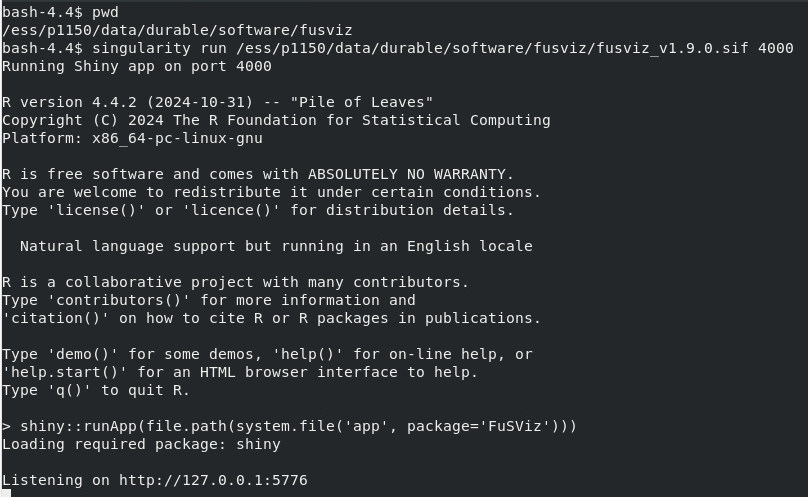

```bash
# Launch image from fuzviz folder
cd $DURABLE/software/fusviz

singularity run fusviz_v1.9.0.sif 4000
```

**Figure 23.** When launching the fusviz image, you will see the same text in the terminal

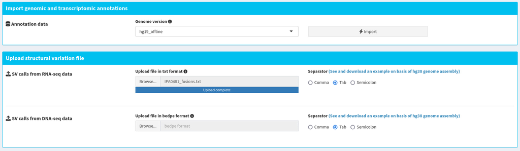

**Figure 24.** Select genome and load SV table

- Click On the *Two-way* tab (left-side). Now you will see three tabs in the top. Click on the *Overview_plot* button.
  - Manually select the two genes involved in the fusion and their breakpoints (position in the genome where the fusion occurred). These numbers are the same values provided in the SV table (Figure 26).
  - You will see a plot in the right side with all the transcripts associated to each of the selected genes (upstream: green; downstream: orange), the location in their chromosomes and the parts of the transcript connected through the fusion.
  - Click on the *Download plot* at the bottom to save the figure.
  - Rename downloaded plot: `${SAMPLE_ID}_Gene1-Gene2_overview.pdf`

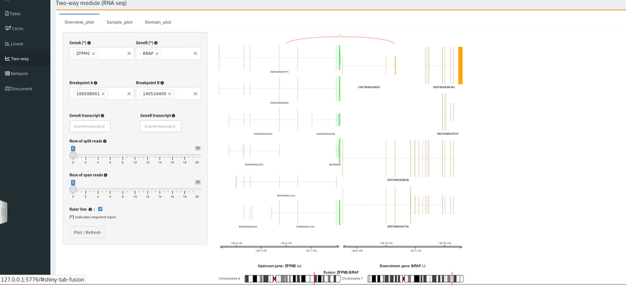

**Figure 26.** The *Overview_plot* option is located in the *Two-way* tab in the left menu. Select the genes and their breakpoints manually (left side) to see the connected parts in the transcripts (right side). Upstream gene: green; Downstream gene: orange

- Click On the *Two-way* tab (left-side). Now you will see three tabs in the top. Click on the *Domain_plot* button.
  - Manually select the two genes involved in the fusion, select one transcript for each gene and their breakpoints (position in the genome where the fusion occurred).
  - You will see a plot in the right side with the exons and annotated protein domains across the selected transcripts (upstream: green; downstream: orange). The arrow connecting the two transcripts indicates the place where the fusion occurs (Figure 27).
  - Click on the *Download plot* at the bottom to save the figure.
  - Rename downloaded plot: `${SAMPLE_ID}_Gene1-Gene2_domain.pdf`

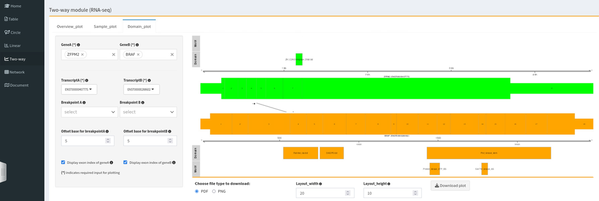

**Figure 27.** The *Domain_plot* option is located in the *Two-way* tab in the left menu. Select the genes, one transcript per gene and their breakpoints manually (left side) to see the exons and protein domains of the fused transcripts (right side). Upstream gene: green; Downstream gene: orange